# Der Rosenkavalier

## Handlung

ERSTER AUFZUG  
Nach gemeinsam verbrachter Liebesnacht erwachen die Feldmarschallin Fürstin Werdenberg und ihr junger Liebhaber, Graf Octavian Rofrano. Das Frühstück wird jedoch von einer näherkommenden Männerstimme gestört: Entgegen der Befürchtungen ist es aber nicht der vorzeitig heimkehrende Feldmarschall, sondern Baron Ochs auf Lerchenau, ein verarmter Vetter der Marschallin vom Land. Während sich Octavian als Kammerzofe verkleidet, berichtet Ochs der Marschallin von seinen Hochzeitsplänen: Er, sonst kein Kind von Traurigkeit, will zwecks Konsolidierung Sophie ehelichen, die Tochter des steinreichen Neuadligen Faninal. Dafür erbittet er von der Marschallin den Vorschlag eines standesgemäßen Rosenkavaliers, der am Hochzeitsmorgen durch die Überreichung einer Rose der Braut die Ankunft des Bräutigams ankündigen soll. Die Marschallin schlägt Octavian vor, von dem sie Ochs ein Bild zeigt. Der wundert sich über die Ähnlichkeit mit der Kammerzofe »Mariandl«, auf die er bereits ein Auge geworfen und sie daher zum Souper eingeladen hat.  
Beim Lever bei der Marschallin herrscht Trubel: Es kommen diverse Bittsteller sowie ein italienischer Tenor und ein Papierkünstler; Ochs streitet mit dem Notar über Details des Ehevertrags; das Intrigantenpaar Valzacchi und Annina bietet Ochs seine Dienste an.  
Die Marschallin lässt alle hinauswerfen und bleibt melancholisch verstimmt zurück. Sie räsoniert über die junge Sophie, der eine Vernunftehe wie die ihre bevorsteht, und ihr eigenes Altern. Den zurückverwandelten Octavian schickt sie mit dem Hinweis fort, dass er sie früher oder später für eine Jüngere verlassen werde.

ZWEITER AUFZUG  
Im Hause Faninal erwartet alles gespannt die Ankunft des Rosenkavaliers. Faninal freut sich auf seinen mit der Heirat verbundenen gesellschaftlichen Aufstieg, die Duenna Marianne Leitmetzerin über die gute Partie und Sophie auf die Ehe allgemein. Octavian tritt ein und überreicht Sophie die Rose, wobei sich beide zueinander hingezogen fühlen, was sie in tiefe Verlegenheit stürzt. Ganz und gar nicht angezogen fühlt sich Sophie zu ihrem danach eintreffenden künftigen Ehemann und dessen grobem Verhalten.  
Als Faninal und Ochs sich nebenan der Unterzeichnung des Ehevertrags widmen, gestehen sich Octavian und Sophie ihre Zuneigung. Valzacchi und Annina ertappen sie bei einem Kuss. Ochs ist darüber nicht erbost, auch dann nicht, als Octavian ihm mitteilt, dass Sophie ihn nicht heiraten wolle. Als ihn dann der junge Widersacher in Rage zum Duell herausfordert und leicht mit dem Degen verletzt, löst das jedoch einen Tumult aus. Faninal wirft Octavian hinaus, fürchtet eine gesellschaftliche Blamage und will seine widerstrebende Tochter zur Heirat zwingen.  
Inzwischen hat sich Ochs wieder berappelt und flucht auf Octavian und die Zustände in der Stadt. Seine Laune erhellt sich, als Annina ihm einen Brief von »Mariandl« bringt, die seine Einladung annimmt.

DRITTER AUFZUG  
Ochs empfängt »Mariandl« zum Souper und bemüht sich um eine romantische Atmosphäre. Allerdings fühlt er sich während seiner Annäherungsversuche immer wieder unangenehm an Octavian erinnert. Merkwürdige Erscheinungen werfen ihn zusehends aus der Bahn, bis die verkleidete Annina mit Kindern im Schlepptau hereinplatzt und Ochs vorwirft, sie – seine angebliche Ehefrau – sitzen gelassen zu haben. Der Krach ruft die Sittenpolizei auf den Plan. Der Kommissar verhört Ochs, der in die Enge getrieben »Mariandl« als seine Braut, das Fräulein Faninal, ausgibt. Da kommen die echte Braut und ihr fassungsloser Vater hinzu, der vor lauter Skandal einen Schwächeanfall erleidet. Während sich »Mariandl« wieder in Octavian verwandelt, trifft überraschend auch die Feldmarschallin ein. Sie beschwichtigt den Kommissar, klärt die Maskerade auf, erteilt den Hochzeitsplänen eine Absage und fordert Ochs nachdrücklich zur Abreise auf.  
Die Marschallin bleibt allein mit Sophie und Octavian zurück, wobei sie deren Gefühle sofort durchschaut. Sie leistet Verzicht und gibt Octavian frei. Aber ob Octavian mit Sophie glücklich werden wird?

## Pressestimmen

> »Einen prächtigeren, geschmackvolleren, opulenteren „Rosenkavalier“ hat man kaum je gesehen.«

> **Süddeutsche Zeitung, 11. Februar 2020**

> »Großartig lebendig und einfallsreich ist seine [Andre Hellers] Personenregie, zumal er sich auf fabelhafte Sängerdarsteller verlassen kann.«

> **Süddeutsche Zeitung, 11. Februar 2020**

> »Michèle Losier ist mit passend androgynem Mezzosoprantimbre ein quecksilbrig draufgängerischer Octavian, den man seinen jugendlichen Unbedingtheitswillen und seine Zerrissenheit zwischen der Marschallin und der Sophie ebenso abnimmt, wie das störrische Mariandl.«

> **Süddeutsche Zeitung, 11. Februar 2020**

> »Camilla Nylund modelliert als stets souveräne Marschallin ihren warmen, flutenden Sopran in feinsten Nuancen, von der euphorischen Aufgekratztheit der Anfangsszene über die zarte Emphase der Liebhaberin bis zur ganz nach Innen genommenen Melancholie ihres Monologs über die Zeit.«

> **Süddeutsche Zeitung, 11. Februar 2020**

> »Abgründig schmierig und authentisch wienerisch färbt der großartige Günther Groissböck seine Diktion als Ochs ein und lässt in seinen kraftvollen Basslinien immer wieder gelungen die gewalttätigen Züge der Partie hervorbrechen.«

> **Süddeutsche Zeitung, 11. Februar 2020**

> »Zubin Mehta zaubert in breiten Tempi eine wogende Walzerkette hervor«

> **Süddeutsche Zeitung, 11. Februar 2020**

> »Die Bühnenbildnerin Xenia Hausner hat sich für das Schlafgemach der Marschallin vom seidenreichen Japonismus um 1900 inspirieren lassen, für das Stadtpalais Faninals den blattgoldfetten Prunk der Wiener Sezession mit Gustav Klimts Beethovenfries gekrönt und aus dem Vorstadt-Beisl des dritten Akts ein orientalisches Palmenhaus gemacht. Das alles, auch die zeitlos-luxuriöse Kostümierung durch Arthur Arbesser, ist opulent und farbenfroh; die Bühne perfektioniert durch vorgestreckte Seitenflügel die ohnehin schon fabelhafte Akustik der Staatsoper so weit, dass man den Text der Singenden unglaublich deutlich versteht.«

> **Frankfurter Allgemeine Zeitung, 11. Februar 2020**

> »Nadine Sierra singt und spielt die arglose Unbeholfenheit der Sophie im zweiten Akt so hinreißend, dass Michèle Losier als Octavian gar nicht anders kann, als sich Hals über Kopf in dieses Geschöpf zu verlieben. Dieser Zauber aus Zutraulichkeit, Schutzlosigkeit und Charme ist bei Sierra unwiderstehlich.«

> **Frankfurter Allgemeine Zeitung, 11. Februar 2020**

> »Günther Groissböck als Baron Ochs ist unübertrefflich: perfekt in seiner wienerischen Diktion, souverän in seinem Geschmack, ein Komödiant ohne Schmiere, stimmlich ein Weltmann von Wohlklang und feinster Artikulation, dabei elegant in der Führung seiner leichtfüßigen Bass-Stimme.«

> **Frankfurter Allgemeine Zeitung, 11. Februar 2020**

> »Michèle Losier als dunkel glühender, ebenso leichter wie leidenschaftlicher Octavian ist die große Entdeckung des Abends.«

> **Frankfurter Allgemeine Zeitung, 11. Februar 2020**

> »Die Musik blickt hier in Seelen-Abgründe, die faszinierend funkeln, transzendiert philosophische Fragen. Es sind diese Momente, in denen die Staatskapelle so genau und klar klingt, als dirigiere Zubin Mehta mit dem Seziermesser. Auch die Klangräusche blühen herrlich vielfältig auf.«

> **Berliner Morgenpost, 11. Februar 2020**

> »Denn der Ochs ist hier kein polternder Schmerbauch, sondern Günther Groissböck, vermutlich der beste Ochs der Gegenwart, ein viriler Don Juan ohne Manieren, aber doch mit erstaunlich viel Erotik in Haltung und Stimme. Diese sonore Mittellage! Diese Textdurchdringung! Diese raumgreifende Körperlichkeit!«

> **Berliner Morgenpost, 11. Februar 2020**

> »Herrlich mühelos klingt ihr [Nadine Sierras] jugendlicher Sopran, ein einziges Jauchzen und Flehen, das sich äußerst harmonisch mit Michèle Losiers zunehmend aufblühenden Mezzo vereint, um beim Schlussduett die Zeit stillstehen zu lassen.«

> **Berliner Morgenpost, 11. Februar 2020**

> »Camilla Nylund als Marschallin, die stimmliche und darstellerische Statur vielschichtig mit dem Eindruck von Verletzlichkeit, gar Zartheit zu verbinden weiß; Michèle Losier als energiegeladener Octavian, Nadine Sierra als Sophie, der man die kindliche Naivität ebenso abnimmt wie den Ernst ihrer Gefühle.«

> **Berliner Zeitung, 11. Februar 2020**

> »Wie die Zeit vergeht! Camilla Nylund singt davon. Man sitzt da und spürt es bis unter die Haut. Die finnische Sängerin singt ihre Rolle nicht nur, sie füllt sie aus mit ihrer ganzen Person.«

> **taz, 11. Februar 2020**

> »Es ist zum Weinen schön, getragen vom virtuosen Wohlklang der Musik von Richard Strauss, durchsetzt von eher ehrfürchtigen als ironischen Zitaten seiner eigenen Vergangenheit. Zubin Mehta dirigiert sie, die Staatskapelle spielt sie, und damit ist schon alles gesagt: besser geht es nicht. So klingt großer Oper bis heute.«

> **taz, 11. Februar 2020**

> »Mit seiner [Andre Hellers] Rosenkavalier-Inszenierung an der Berliner Staatsoper setzt er der Makellosigkeit nun ein Denkmal – und trifft das Stück und all jene ins Mark, die mit dem Dichter Hugo von Hoffmannsthal und dem Komponisten Richard Strauss ihr Opernleben verbracht haben. Das mache ihm, Heller, heute einmal einer nach.«

> **Die Zeit, 13. Februar 2020**

> »Mehtas Walzer sind Sehnsüchte, Antithesen zur schrecklichen Welt da draußen, stets mit einem sentimentalen Ton.«

> **Kurier, 11. Februar 2020**

> »Er [Günther Groissböck] behält in aller Obszönität stets die Eleganz, seine Diktion ist perfekt, seine Studie eines Adeligen mit schöner Vergangenheit und schlechten Manieren ebenso. Er ist die Idealbesetzung.«

> **Kurier, 11. Februar 2020**

> »Auch Camilla Nylund als Feldmarschallin besticht mit traumhafter Phrasierung, stimmlichem Glanz, großer Noblesse – eine exzellente Strauss-Sängerin […].«

> **Kurier, 11. Februar 2020**

> »Heller (Mitarbeit bei der Regie: Wolfgang Schilly) erzählt vor allem im ersten Akt detailvoll lebendig: Der Weg der noblen Marschallin von horizontalen Freuden (mit dem jungen Geliebten Octavian) zur obligaten morgendlichen Frisurgestaltung gelingt als leichtfüßiges Kammerspiel. Nachdem sodann alle Bittsteller in einer zirkusartigen Szene ihre Anliegen vorgebracht haben – unter anderem Atalla Ayan als sehr solider Tenor –, wird die melancholische Reflexion der Marschallin aber zum poetischen Höhepunkt. Camilla Nylunds Sopran betört dabei durch Strahlkraft und innigen Ausdruck. Und tut dies auch im Finale.«

> **Der Standard, 11. Februar 2020**

> »Seinen [Günther Groissböcks] Ochs kann man sich nicht gesanglich souveräner, beredter phrasierend und natürlicher im Gehabe vorstellen.«

> **Die Presse, 11. Februar 2020**

> »Mit Camilla Nylund als Marschallin, Günther Groissböck als Ochs, Nadine Sierra als Sophie und Michèle Losier als Octavian ist eine herausragende Besetzung am Werk und das kräftige, fein aufeinander abgestimmte Panorama ihrer Stimmen wird von Zubin Mehta am Pult der Staatskapelle ideal zur Geltung gebracht. Geschmackvoll, schlank und anschmiegsam tönt es aus dem Graben, wunderbare Bläsersoli hinterlassen bleibende Eindrücke.«

> **APA/Austrian Presse Agentur, 10. Februar 2020**

## Programmbuch

[Download](https://www.staatsoper-berlin.de/downloads-b/de/produktion/7549/programmbuch/947a1d9e92a64178fe77fc90d978feba/Der_Rosenkavalier_Programmheft_1920.pdf)

## Mehr erfahren

### »Der Rosenkavalier« und die Moderne

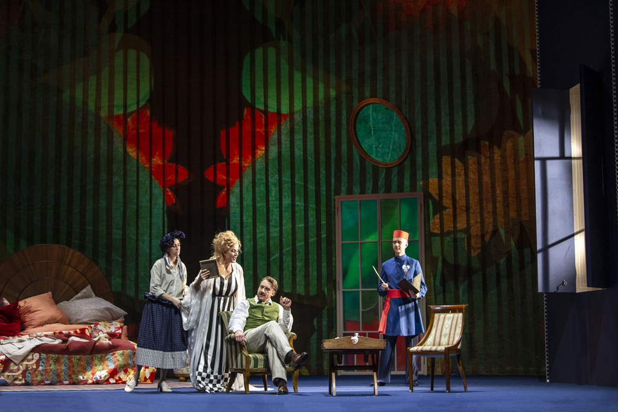

- Die Modernität des »Rosenkavaliers« ist unter der Oberfläche zu finden: Dramaturg Benjamin Wäntig beleuchtet dieses Thema in einem Essay auf dem Blog...

### Schönheit und Sinnlichkeit – Ein Gespräch mit André Heller

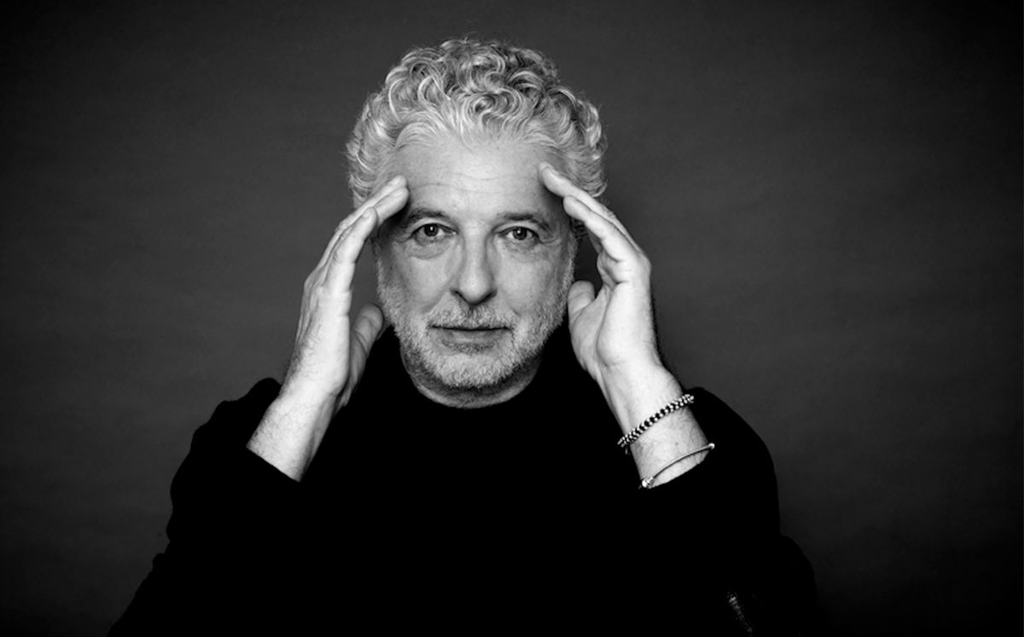

- Während der Proben für »Der Rosenkavalier« traf Dramaturg Benjamin Wäntig den Regisseuren der Neuproduktion zum Interview.

[figure not shown]